# Preparación de datos

lunes 02 mayo 2022 16:30:25

# 1 Setup

```r
knitr::opts_chunk$set(
    echo = FALSE,
    message = FALSE,
    warning = FALSE,
    fig.height = 18,
    fig.width = 11,
    cache = TRUE
)
options(scipen=9999) # desactivar notacion cientifica
remove(list = ls()) #limpieza del entorno de trabajo
```

# 2 Análisis descriptivo

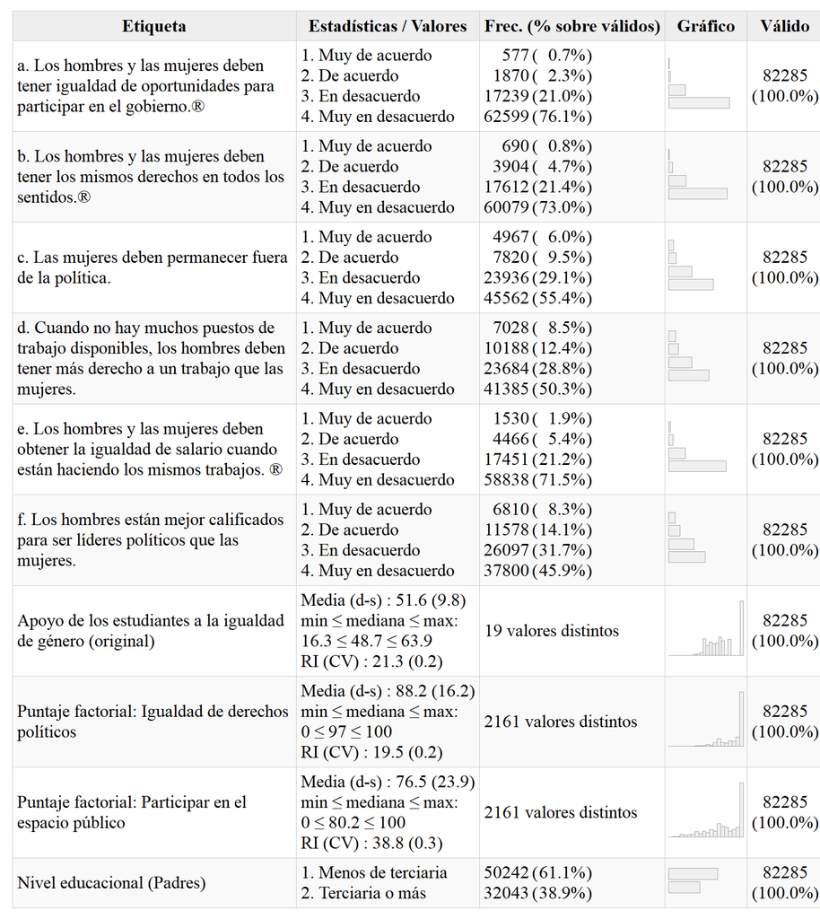

| **Etiqueta** | **Estadísticas / Valores** | **Frec. (% sobre válidos)** | **Gráfico** | **Válido** |
| --- | --- | --- | --- | --- |
| a. Los hombres y las mujeres deben tener igualdad de oportunidades para participar en el gobierno.® | 1. Muy de acuerdo 2. De acuerdo 3. En desacuerdo 4. Muy en desacuerdo | 577 ( 0.7% ) 1870 ( 2.3% ) 17239 ( 21.0% ) 62599 ( 76.1% ) |  | 82285 (100.0%) |
| b. Los hombres y las mujeres deben tener los mismos derechos en todos los sentidos.® | 1. Muy de acuerdo 2. De acuerdo 3. En desacuerdo 4. Muy en desacuerdo | 690 ( 0.8% ) 3904 ( 4.7% ) 17612 ( 21.4% ) 60079 ( 73.0% ) |  | 82285 (100.0%) |
| c. Las mujeres deben permanecer fuera de la política. | 1. Muy de acuerdo 2. De acuerdo 3. En desacuerdo 4. Muy en desacuerdo | 4967 ( 6.0% ) 7820 ( 9.5% ) 23936 ( 29.1% ) 45562 ( 55.4% ) |  | 82285 (100.0%) |
| d. Cuando no hay muchos puestos de trabajo disponibles, los hombres deben tener más derecho a un trabajo que las mujeres. | 1. Muy de acuerdo 2. De acuerdo 3. En desacuerdo 4. Muy en desacuerdo | 7028 ( 8.5% ) 10188 ( 12.4% ) 23684 ( 28.8% ) 41385 ( 50.3% ) |  | 82285 (100.0%) |
| e. Los hombres y las mujeres deben obtener la igualdad de salario cuando están haciendo los mismos trabajos. ® | 1. Muy de acuerdo 2. De acuerdo 3. En desacuerdo 4. Muy en desacuerdo | 1530 ( 1.9% ) 4466 ( 5.4% ) 17451 ( 21.2% ) 58838 ( 71.5% ) |  | 82285 (100.0%) |
| f. Los hombres están mejor calificados para ser líderes políticos que las mujeres. | 1. Muy de acuerdo 2. De acuerdo 3. En desacuerdo 4. Muy en desacuerdo | 6810 ( 8.3% ) 11578 ( 14.1% ) 26097 ( 31.7% ) 37800 ( 45.9% ) |  | 82285 (100.0%) |
| Apoyo de los estudiantes a la igualdad de género (original) | Media (d-s) : 51.6 (9.8) min ≤ mediana ≤ max: 16.3 ≤ 48.7 ≤ 63.9 RI (CV) : 21.3 (0.2) | 19 valores distintos |  | 82285 (100.0%) |
| Puntaje factorial: Igualdad de derechos políticos | Media (d-s) : 88.2 (16.2) min ≤ mediana ≤ max: 0 ≤ 97 ≤ 100 RI (CV) : 19.5 (0.2) | 2161 valores distintos |  | 82285 (100.0%) |
| Puntaje factorial: Participar en el espacio público | Media (d-s) : 76.5 (23.9) min ≤ mediana ≤ max: 0 ≤ 80.2 ≤ 100 RI (CV) : 38.8 (0.3) | 2161 valores distintos |  | 82285 (100.0%) |
| Nivel educacional (Padres) | 1. Menos de terciaria 2. Terciaria o más | 50242 ( 61.1% ) 32043 ( 38.9% ) |  | 82285 (100.0%) |

Muestra de países participantes en ICCS

| País | Total de escuelas | Total de estudiantes |
| --- | --- | --- |
| Alemania | 59 | 1.196 |
| Bélgica | 162 | 2.566 |
| Bulgaria | 147 | 2.602 |
| Chile | 178 | 4.508 |
| Colombia | 150 | 4.829 |
| Corea del Sur | 93 | 2.447 |
| Croacia | 175 | 3.661 |
| Dinamarca | 183 | 5.103 |
| Eslovenia | 145 | 2.605 |
| Estonia | 164 | 2.613 |
| Finlandia | 179 | 2.797 |
| Italia | 170 | 3.203 |
| Letonia | 147 | 2.733 |
| Lituania | 181 | 3.162 |
| Malta | 47 | 3.040 |
| México | 211 | 4.861 |
| Noruega | 148 | 5.265 |
| Países Bajos | 123 | 2.485 |
| Perú | 206 | 4.576 |
| RAE de Hong Kong (China) | 91 | 2.347 |
| República Dominicana | 141 | 2.949 |
| Rusia | 352 | 6.484 |
| Suecia | 154 | 2.454 |
| Taiwán | 141 | 3.799 |

Nota: Elaboración propia en base a datos de ICSS 2016(N = 82.285)

Muestra de países participantes en ICCS

Código ICCS

Apoyo de los estudiantes a la igualdad de género

is3g24a

1. Los hombres y las mujeres deben tener igualdad de oportunidades para participar en el gobierno.®

is3g24b

2. Los hombres y las mujeres deben tener los mismos derechos en todos los sentidos.®

is3g24c

3. Las mujeres deben permanecer fuera de la política.

is3g24d

4. Cuando no hay muchos puestos de trabajo disponibles, los hombres deben tener más derecho a un trabajo que las mujeres.

is3g24e

5. Los hombres y las mujeres deben obtener la igualdad de salario cuando están haciendo los mismos trabajos. ®

is3g24f

6. Los hombres están mejor calificados para ser líderes políticos que las mujeres.

Nota: Elaboración propia en base a datos de ICSS 2016. (N = 82.285). La escala de respuesta utilizada corresponde a (1) Muy de acuerdo; (2) De acuerdo; (3) En desacuerdo; (4) Totalmente en desacuerdo. ® Items invertidos

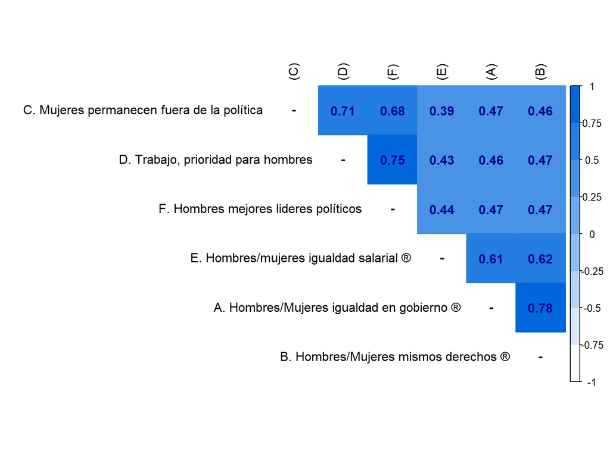

Matriz de correlaciones policóricas para Apoyo de los estudiantes a la igualdad de género

Muestra de países participantes en ICCS

Código ICCS

Actitudes positivas de los estudiantes hacia su país de residencia

is3g27a

1. La (bandera del país de prueba) es importante para mí

is3g27b

2. Tengo gran respeto por (país de prueba)

is3g27c

3. En (país de prueba) deberíamos estar orgullosos de lo que hemos logrado

is3g27d

4. Estoy orgulloso de vivir en (país de prueba)

is3g27e

5. (país de prueba) es un mejor país para vivir que en la mayoría de los otros países

Nota: Elaboración propia en base a datos de ICSS 2016. (N = 82.285). La escala de respuesta utilizada corresponde a (1) Muy de acuerdo; (2) De acuerdo; (3) En desacuerdo; (4) Totalmente en desacuerdo.

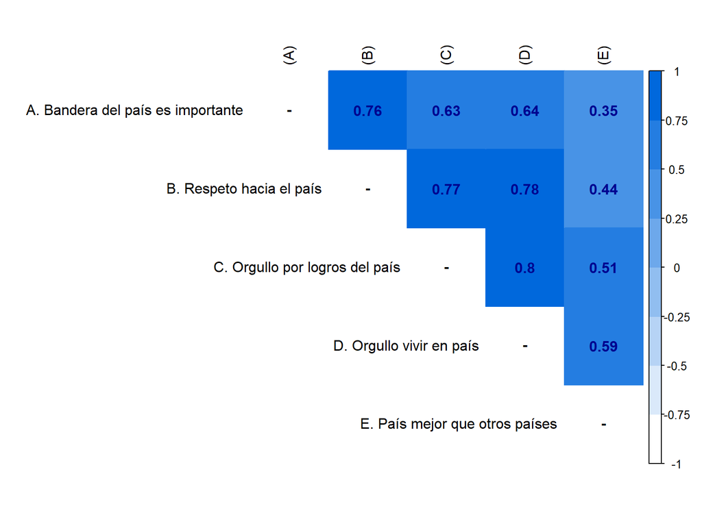

Matriz de correlaciones policóricas para actitudes positivas de los estudiantes hacia su país de residencia

# 3 Análisis multivariado

## Igualdad de género

```
## [1] "IS3G24A"      "IS3G24B"      "IS3G24C"      "IS3G24D"      "IS3G24E"
## [6] "IS3G24F"      "country_name"
```

Resumen de ajuste según número de dimensiones para modelo de medición de Igualdad de género

| Dimensiones | $N$ | Estimador | $\chi^2$ | gl | CFI | TLI | RMSEA |
| --- | --- | --- | --- | --- | --- | --- | --- |
| 1 | 82285 | ML | 25258.04 | 216 | 0.968 | 0.946 | 0.184 |
| 2 | 82285 | ML | 1915.63 | 192 | 0.998 | 0.996 | 0.051 |

Resumen de ajuste según países para modelo de medición de Igualdad de género (una dimensión)

| País | $\chi^2$ | gl | $N$ | CFI | TLI | RMSEA |
| --- | --- | --- | --- | --- | --- | --- |
| Alemania | 118.366 | 9 | 1196 | 0.993 | 0.988 | 0.101 |
| Estonia | 251.709 | 9 | 2613 | 0.988 | 0.980 | 0.102 |
| Bélgica | 296.087 | 9 | 2566 | 0.982 | 0.969 | 0.112 |
| Suecia | 342.247 | 9 | 2454 | 0.991 | 0.984 | 0.123 |
| Italia | 398.086 | 9 | 3203 | 0.982 | 0.970 | 0.116 |
| Dinamarca | 442.049 | 9 | 5103 | 0.994 | 0.990 | 0.097 |
| Eslovenia | 451.162 | 9 | 2605 | 0.984 | 0.974 | 0.137 |
| Finlandia | 469.494 | 9 | 2797 | 0.990 | 0.984 | 0.135 |
| Países Bajos | 483.787 | 9 | 2485 | 0.982 | 0.969 | 0.146 |
| Letonia | 492.912 | 9 | 2733 | 0.972 | 0.954 | 0.140 |
| Malta | 547.944 | 9 | 3040 | 0.974 | 0.957 | 0.140 |
| Croacia | 844.827 | 9 | 3661 | 0.976 | 0.960 | 0.159 |
| Bulgaria | 955.709 | 9 | 2602 | 0.932 | 0.886 | 0.201 |
| Noruega | 993.820 | 9 | 5265 | 0.987 | 0.979 | 0.144 |
| Lituania | 1033.726 | 9 | 3162 | 0.957 | 0.928 | 0.190 |
| Colombia | 1141.861 | 9 | 4829 | 0.957 | 0.928 | 0.161 |
| República Dominicana | 1149.107 | 9 | 2949 | 0.821 | 0.701 | 0.207 |
| Taiwán | 1168.283 | 9 | 3799 | 0.979 | 0.965 | 0.184 |
| Perú | 1223.502 | 9 | 4576 | 0.950 | 0.917 | 0.172 |
| Corea del Sur | 1712.390 | 9 | 2447 | 0.945 | 0.909 | 0.278 |
| Rusia | 2117.466 | 9 | 6484 | 0.928 | 0.881 | 0.190 |
| RAE de Hong Kong (China) | 2315.382 | 9 | 2347 | 0.956 | 0.927 | 0.331 |
| México | 3082.369 | 9 | 4861 | 0.857 | 0.762 | 0.265 |
| Chile | 3225.752 | 9 | 4508 | 0.946 | 0.910 | 0.282 |

```
## x <lgl>
## # total N=24 valid N=24 mean=0.75 sd=0.44
##
## Value |  N | Raw % | Valid % | Cum. %
## -------------------------------------
## FALSE |  6 |    25 |      25 |     25
## TRUE  | 18 |    75 |      75 |    100
## <NA>  |  0 |     0 |    <NA> |   <NA>
```

```
## x <lgl>
## # total N=24 valid N=24 mean=0.58 sd=0.50
##
## Value |  N | Raw % | Valid % | Cum. %
## -------------------------------------
## FALSE | 10 | 41.67 |   41.67 |  41.67
## TRUE  | 14 | 58.33 |   58.33 | 100.00
## <NA>  |  0 |  0.00 |    <NA> |   <NA>
```

```
## x <lgl>
## # total N=24 valid N=24 mean=0.00 sd=0.00
##
## Value |  N | Raw % | Valid % | Cum. %
## -------------------------------------
## FALSE | 24 |   100 |     100 |    100
## <NA>  |  0 |     0 |    <NA> |   <NA>
```

```
## x <lgl>
## # total N=24 valid N=24 mean=0.75 sd=0.44
##
## Value |  N | Raw % | Valid % | Cum. %
## -------------------------------------
## FALSE |  6 |    25 |      25 |     25
## TRUE  | 18 |    75 |      75 |    100
## <NA>  |  0 |     0 |    <NA> |   <NA>
```

Resumen de ajuste según países para modelo de medición de Igualdad de género (dos dimensiones)

| País | $\chi^2$ | gl | $N$ | CFI | TLI | RMSEA |
| --- | --- | --- | --- | --- | --- | --- |
| Letonia | 14.950 | 8 | 2733 | 1.000 | 0.999 | 0.018 |
| Alemania | 15.519 | 8 | 1196 | 0.999 | 0.999 | 0.028 |
| Colombia | 25.295 | 8 | 4829 | 0.999 | 0.999 | 0.021 |
| Italia | 29.550 | 8 | 3203 | 0.999 | 0.998 | 0.029 |
| Perú | 33.820 | 8 | 4576 | 0.999 | 0.998 | 0.027 |
| República Dominicana | 33.939 | 8 | 2949 | 0.996 | 0.992 | 0.033 |
| Bulgaria | 34.414 | 8 | 2602 | 0.998 | 0.996 | 0.036 |
| Eslovenia | 35.358 | 8 | 2605 | 0.999 | 0.998 | 0.036 |
| Corea del Sur | 36.761 | 8 | 2447 | 0.999 | 0.998 | 0.038 |
| Croacia | 38.514 | 8 | 3661 | 0.999 | 0.998 | 0.032 |
| Bélgica | 39.174 | 8 | 2566 | 0.998 | 0.996 | 0.039 |
| Estonia | 39.318 | 8 | 2613 | 0.998 | 0.997 | 0.039 |
| Malta | 40.559 | 8 | 3040 | 0.998 | 0.997 | 0.037 |
| Taiwán | 59.451 | 8 | 3799 | 0.999 | 0.998 | 0.041 |
| Noruega | 61.285 | 8 | 5265 | 0.999 | 0.999 | 0.036 |
| Países Bajos | 62.567 | 8 | 2485 | 0.998 | 0.996 | 0.052 |
| Rusia | 65.691 | 8 | 6484 | 0.998 | 0.996 | 0.033 |
| Lituania | 70.387 | 8 | 3162 | 0.997 | 0.995 | 0.050 |
| Suecia | 85.914 | 8 | 2454 | 0.998 | 0.996 | 0.063 |
| Dinamarca | 86.927 | 8 | 5103 | 0.999 | 0.998 | 0.044 |
| Chile | 96.270 | 8 | 4508 | 0.999 | 0.997 | 0.049 |
| Finlandia | 102.427 | 8 | 2797 | 0.998 | 0.996 | 0.065 |
| RAE de Hong Kong (China) | 121.010 | 8 | 2347 | 0.998 | 0.996 | 0.078 |
| México | 686.530 | 8 | 4861 | 0.968 | 0.941 | 0.132 |

```
## x <lgl>
## # total N=24 valid N=24 mean=1.00 sd=0.00
##
## Value |  N | Raw % | Valid % | Cum. %
## -------------------------------------
## TRUE  | 24 |   100 |     100 |    100
## <NA>  |  0 |     0 |    <NA> |   <NA>
```

```
## x <lgl>
## # total N=24 valid N=24 mean=0.96 sd=0.20
##
## Value |  N | Raw % | Valid % | Cum. %
## -------------------------------------
## FALSE |  1 |  4.17 |    4.17 |   4.17
## TRUE  | 23 | 95.83 |   95.83 | 100.00
## <NA>  |  0 |  0.00 |    <NA> |   <NA>
```

```
## x <lgl>
## # total N=24 valid N=24 mean=0.83 sd=0.38
##
## Value |  N | Raw % | Valid % | Cum. %
## -------------------------------------
## FALSE |  4 | 16.67 |   16.67 |  16.67
## TRUE  | 20 | 83.33 |   83.33 | 100.00
## <NA>  |  0 |  0.00 |    <NA> |   <NA>
```

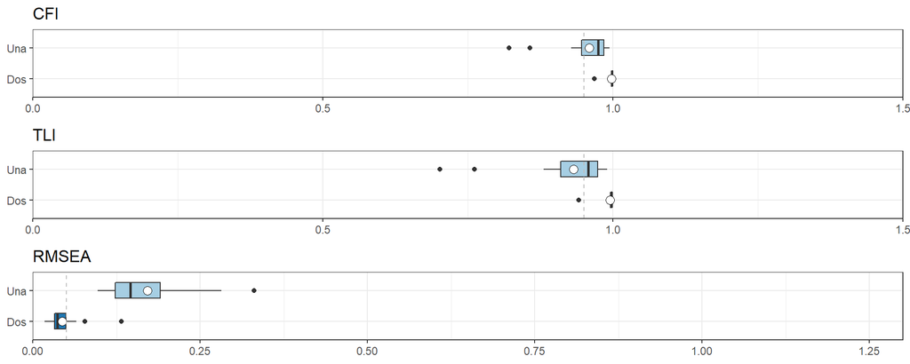

Invarianza multigrupo para modelo de medición de Igualdad de género (dos dimensiones)

| Model | $\chi^2 (\text{df})$ | CFI | RMSEA (90 CI) | $\Delta \chi^2 (\Delta \text{df}$) | $\Delta \text{CFI}$ | $\Delta \text{RMSEA}$ | Decisión |
| --- | --- | --- | --- | --- | --- | --- | --- |
| Configural | 1915.63 (192) | 0.998 | 0.051 (0.049-0.053) | 0 (0) | 0.000 | 0.000 |  |
| Débil | 2673.4 (284) | 0.997 | 0.05 (0.048-0.051) | 757.766 (92) *** | -0.001 | -0.002 | Rechaza |
| Fuerte | 9743.26 (514) | 0.988 | 0.072 (0.071-0.074) | 7069.86 (230) *** | -0.009 | 0.023 | Rechaza |
| Estricta | 18145.79 (652) | 0.978 | 0.088 (0.087-0.09) | 8402.534 (138) *** | -0.011 | 0.016 | Rechaza |

Nota: ***p < 0.001

- sort de tablas de fit meas por país y ordenar según x2
- revisar posibilidad de fuentes de invarianza x país
- son todos los países iguales en fit?

## 3.1 Modelos

```
##
##  C:\Users\Julio\AppData\Local\Temp\Rtmpk5pPXs\downloaded_packages
```

```
##
##     0     1
## 50242 32043
```

```
## x <numeric>
## # total N=82285 valid N=82285 mean=0.39 sd=0.49
##
## Value |     N | Raw % | Valid % | Cum. %
## ----------------------------------------
##     0 | 50242 | 61.06 |   61.06 |  61.06
##     1 | 32043 | 38.94 |   38.94 | 100.00
##  <NA> |     0 |  0.00 |    <NA> |   <NA>
```

Diferencias promedio entre estudiantes con y sin padres universitarios y los diferentes modelos de factores de igualdad de género

[output not shown]

Nota: Elaboración propia en base a datos de ICSS 2016. (N = 82.285). $‘.’p$ < 0.10; $*p$ < 0.05 ;$**p$ < 0.01; $***p$ < 0.001

```
##
##  C:\Users\Julio\AppData\Local\Temp\Rtmpk5pPXs\downloaded_packages
```

```
##
##     0     1
## 50242 32043
```

```
## x <numeric>
## # total N=82285 valid N=82285 mean=0.39 sd=0.49
##
## Value |     N | Raw % | Valid % | Cum. %
## ----------------------------------------
##     0 | 50242 | 61.06 |   61.06 |  61.06
##     1 | 32043 | 38.94 |   38.94 | 100.00
##  <NA> |     0 |  0.00 |    <NA> |   <NA>
```

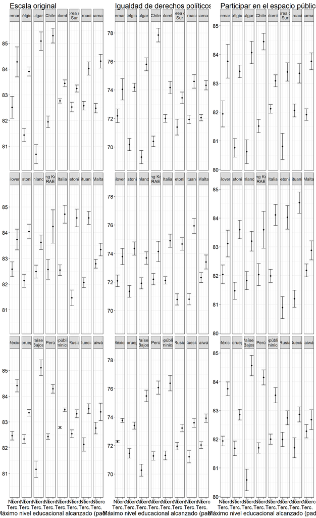

- variable bruta iccs
- variable latente original
- variable latente refinada
- correlación de 24 países actitude~educación, indicador compuesto S_HiSCED (polyserial corr)
- ttest 0 = menos de terciaria; 1 = terciaria o más